# Deep Neural Networks

## Topic: Landmark Classification by MLP & CNN

In this notebook, dataset has been extracted from website via https://udacity-dlnfd.s3-us-west-1.amazonaws.com/datasets/landmark_images.zip

### Before implementing code I try to understand neuron network as AJ.Fon suggest thorugh online platform

#### Topic which studied

1. Basic of neuron network include of forward pass / backpropagation / cost(lost) function / params update / optimization algorithms to update weight/bias.
2. Basic numpy - pandas - pytorch framework to help implement deep learning algorithms on datasets
3. Deep learning CNN architecture research included of fully connected layer / hidden layer / CNN layer
4. How to tune model and hyperparameters like dropout / L1-L2 regularization

[figure not shown]

### The Step Ahead

We break the notebook into separate steps.

- Step 0: Download Datasets and pre-processing data / visualize data
- Step 1: Create a MLP to Classfy Landmarks (from Scratch)
- Step 2: Create a CNN to Classify Landmarks (from Scratch)
- Step 3: Create a CNN to Classify Landmarks (using Transfer Learning)
- Step 4: Write Your Landmark Prediction Algorithm

## Step 0: Download Datasets and pre-processing data / visualize data

Unzip the folder and place it in this project's home directory, at the location `/landmark_images`.

Install the following Python modules:

- cv2
- matplotlib
- numpy
- PIL
- torch
- torchvision

```python
# Import neccessary libraries

import os
import numpy as np
import torch
import torchvision
from torchvision import datasets,models,transforms
from torch.utils.data.sampler import SubsetRandomSampler
```

```python
## Specify appropriate transforms, and batch_sizes

# Define params
batch_size = 20
valid_size = 0.2
num_workers = 0

# Define directory
data_dir = 'C:/Users/sam/Desktop/study/Deep_learning/project2/landmark_images/'
train_dir = os.path.join(data_dir,'train')
test_dir = os.path.join(data_dir,'test')

# Load and transform data (Resize and Augmentation)
transform = transforms.Compose([transforms.Resize((128,128)), # input size
                               transforms.ToTensor(),
                               transforms.Normalize((0.5, 0.5, 0.5), (0.5, 0.5, 0.5))])

train_transform = datasets.ImageFolder(train_dir,transform = transform)
test_transform = datasets.ImageFolder(test_dir,transform = transform)
print(f'The Total images : {len(train_transform)+len(test_transform)}')

# Split data and load data
train_data_len = len(train_transform)
train_data_indices = list(range(train_data_len))
np.random.shuffle(train_data_indices)
valid_indices,train_indices = np.split(train_data_indices, [int(train_data_len*valid_size)])

# Create sampler
train_sampler = SubsetRandomSampler(train_indices)
valid_sampler = SubsetRandomSampler(valid_indices)

print(f'The number of training images: {len(train_indices)}')
print(f'The number of validating images: {len(valid_indices)}')
print(f'The number of testing images: {len(test_transform)}')


# Create DataLoader
train_loader = torch.utils.data.DataLoader(train_transform,sampler = train_sampler, batch_size=batch_size, num_workers=num_workers)
valid_loader = torch.utils.data.DataLoader(train_transform,sampler = valid_sampler ,batch_size=batch_size, num_workers=num_workers)
test_loader  = torch.utils.data.DataLoader(test_transform, batch_size=batch_size, shuffle=True, num_workers=num_workers)

loaders_scratch = {'train': train_loader, 'valid': valid_loader, 'test': test_loader}
```

```
The Total images : 6246
The number of training images: 3997
The number of validating images: 999
The number of testing images: 1250
```

```
Counter({0: 100, 1: 100, 2: 100, 3: 100, 4: 100, 5: 100, 6: 100, 7: 100, 8: 100, 9: 100, 10: 100, 11: 100, 12: 100, 13: 100, 14: 100, 15: 100, 16: 100, 17: 100, 18: 100, 19: 100, 20: 100, 21: 100, 22: 100, 23: 100, 24: 100, 25: 100, 26: 100, 27: 100, 28: 100, 29: 100, 30: 100, 31: 100, 32: 100, 33: …
dict_keys([0, 1, 2, 3, 4, 5, 6, 7, 8, 9, 10, 11, 12, 13, 14, 15, 16, 17, 18, 19, 20, 21, 22, 23, 24, 25, 26, 27, 28, 29, 30, 31, 32, 33, 34, 35, 36, 37, 38, 39, 40, 41, 42, 43, 44, 45, 46, 47, 48, 49])
```

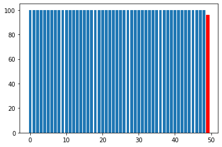

```python
# Check classes distribution

from collections import Counter
import matplotlib.pyplot as plt
%matplotlib inline

dicts = Counter(train_transform.targets)
classes = dicts.keys()
print(dicts)
print(classes)

mybar = plt.bar(classes, dicts.values(), width=0.8)
mybar[49].set_color('r')
plt.show()
```

Firstly, As investigating the dataset, the few images contain unnessary class inside image for example, mountain class also contain thing like people or bird or etc. which mislead to the prediction, Thus I try to resize to 128 size (128*128) as it appear to be typical and suitable size for an image according to original size 800*500 so the parameter will be huge and train so long.So,I decided to training with appropraited size 12*128*3 which = 49152 params.Then,transform the image to Tensor and normalize the tensor of transform images. However, First attemp it does not work out it got only < 20 %. Thus, I think flipping,rotation don't need to be performed as the label can't be detected at edge and the dataset is balance in every classes.

### Visualize a Batch of Training Data 20 images as I have set

This code will display at least 5 images simultaneously

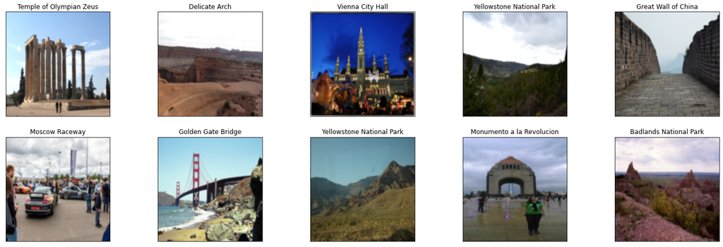

```python
import matplotlib.pyplot as plt
%matplotlib inline

# Define function imshow
def imshow(img):
    img = img / 2 + 0.5  # unnormalize
    plt.imshow(np.transpose(img, (1, 2, 0)))

# Create class names by index
classes = [item[3:].replace("_"," ") for item in train_transform.classes]

# Convert to numpy to display image
dataiter = iter(train_loader)
images,labels = dataiter.next()
images = images.numpy()

# Plot the images with labels
fig = plt.figure(figsize=(25, 8))
# display 10 images
for idx in np.arange(10):
    ax = fig.add_subplot(2, 10/2, idx+1, xticks=[], yticks=[])
    imshow(images[idx])
    ax.set_title(classes[labels[idx]])
```

### Initialize use_cuda variable

```python
# useful variable that tells us whether we should use the GPU
use_cuda = torch.cuda.is_available()
if use_cuda is True:
    print('Using GPU to run model')
else:
    print('Using CPU to run model')
```

```
Using GPU to run model
```

### (IMPLEMENTATION) Specify Loss Function and Optimizer

Use the next code cell to specify a [loss function](http://pytorch.org/docs/stable/nn.html#loss-functions) and [optimizer](http://pytorch.org/docs/stable/optim.html). Save the chosen loss function as `criterion_scratch`, and fill in the function `get_optimizer_scratch` below.

```python
import torch.nn as nn
import torch.optim as optim

criterion_scratch = nn.CrossEntropyLoss()

def get_optimizer_scratch(model):
    optimizer = optim.Adam(model.parameters(),lr=0.00015)
    return optimizer
```

### (Step1) Model Architecture MLP/CNN

Create a CNN/MLP to classify images of landmarks.

```python
# define MLP architecture
import torch.nn as nn

class Simple_classifier(nn.Module):
    def __init__(self):
        super().__init__()
        self.fc1 = nn.Linear(49152,512) # Input size 128*128*3 (w*h*channel)
        self.fc2 = nn.Linear(512,256)
        self.fc3 = nn.Linear(256,128)
        self.fc4 = nn.Linear(128,50) # As we have 50 different labels as output size
        self.dropout = nn.Dropout(p=0.2)
    def forward(self,x):
        # Flatten the input tensor
        x = x.reshape(x.shape[0],-1)
        x = self.dropout(x)
        x = F.relu(self.fc1(x))
        x = self.dropout(x)
        x = F.relu(self.fc2(x))
        x = self.dropout(x)
        x = F.relu(self.fc3(x))
        x = F.log_softmax(self.fc4(x),dim=1)
        return x
# move tensors to GPU if CUDA is available
```

```python
model_mlp = Simple_classifier()
if use_cuda:
    model_mlp.cuda()
print(model_mlp)
```

```
Simple_classifier(
  (fc1): Linear(in_features=49152, out_features=512, bias=True)
  (fc2): Linear(in_features=512, out_features=256, bias=True)
  (fc3): Linear(in_features=256, out_features=128, bias=True)
  (fc4): Linear(in_features=128, out_features=50, bias=True)
  (dropout): Dropout(p=0.2, inplace=False)
)
```

```python
import torch.nn as nn
import torch.nn.functional as F
# define the CNN architecture
class Net(nn.Module):
    ## Choose an architecture, and complete the class
    def __init__(self):
        super(Net, self).__init__()
        # Convolutional layers
        self.conv1 = nn.Conv2d(3, 16, 3, padding=1)
        self.conv2 = nn.Conv2d(16, 32, 3, padding=1)
        self.conv3 = nn.Conv2d(32, 64, 3, padding=1)
        self.conv4 = nn.Conv2d(64, 128, 3, padding=1)
        # max pooling layer
        self.pool = nn.MaxPool2d(2, 2)
        # linear layer1
        self.fc1 = nn.Linear(128 * 8 * 8, 1024)
        # linear layer2
        self.fc2 = nn.Linear(1024, 256)
        # linear layer3
        self.fc3 = nn.Linear(256, 50)
        # dropout layer (p=0.30)
        self.dropout = nn.Dropout(0.30)

    def forward(self, x):
        ## Define forward behavior

        x = self.pool(F.relu(self.conv1(x)))
        x = self.pool(F.relu(self.conv2(x)))
        x = self.pool(F.relu(self.conv3(x)))
        x = self.pool(F.relu(self.conv4(x)))
        x = x.view(-1,128 * 8 * 8 )
        x = self.dropout(x)
        x = F.relu(self.fc1(x))
        x = self.dropout(x)
        x = F.relu(self.fc2(x))
        x = self.dropout(x)
        x = self.fc3(x)

        return x

# instantiate the CNN
model_scratch = Net()

# move tensors to GPU if CUDA is available
if use_cuda:
    model_scratch.cuda()
```

```python
# Show summarize of model's architecture
Net()
```

```
Net(
  (conv1): Conv2d(3, 16, kernel_size=(3, 3), stride=(1, 1), padding=(1, 1))
  (conv2): Conv2d(16, 32, kernel_size=(3, 3), stride=(1, 1), padding=(1, 1))
  (conv3): Conv2d(32, 64, kernel_size=(3, 3), stride=(1, 1), padding=(1, 1))
  (conv4): Conv2d(64, 128, kernel_size=(3, 3), stride=(1, 1), padding=(1, 1))
  (pool): MaxPool2d(kernel_size=2, stride=2, padding=0, dilation=1, ceil_mode=False)
  (fc1): Linear(in_features=8192, out_features=1024, bias=True)
  (fc2): Linear(in_features=1024, out_features=256, bias=True)
  (fc3): Linear(in_features=256, out_features=50, bias=True)
  (dropout): Dropout(p=0.3, inplace=False)
)
```

The layer consist of 4 Convoluted layers, 4 pooling layer, and 3 fully connected layers.

*The First attemp training model wasn't as good as I wanted to be the model overfitting becuase training loss decreased but validate loss still increase.So,I have a bit change my model to prevent even more overfitting by tuning the dropout as the traiing loss went down but the validating loss went up.

### (IMPLEMENTATION) Implement the Training Algorithm

Implement your training algorithm in the code cell below. [Save the final model parameters](http://pytorch.org/docs/master/notes/serialization.html) at the filepath stored in the variable `save_path`.

```python
def train(n_epochs, loaders, model, optimizer, criterion, use_cuda, save_path):
    """returns trained model"""
    # initialize tracker for minimum validation loss
    valid_loss_min = np.Inf

    for epoch in range(1, n_epochs+1):
        # initialize variables to monitor training and validation loss
        train_loss = 0.0
        valid_loss = 0.0

        ###################
        # train the model #
        ###################
        # set the module to training mode
        model.train()
        for batch_idx, (data, target) in enumerate(loaders['train']):
            # move to GPU
            if use_cuda:
                data, target = data.cuda(), target.cuda()

            ## record the average training loss, using something like
            ## train_loss = train_loss + ((1 / (batch_idx + 1)) * (loss.data.item() - train_loss))

            # 1.clear the gradients of all optimized variables
            optimizer.zero_grad()
            # 2.forward pass: compute predicted outputs by passing inputs to the model
            output = model(data)
            # 3.calculate the batch loss
            loss = criterion(output, target)
            # 4.backward pass: compute gradient of the loss with respect to model parameters
            loss.backward()
            # 5.perform a single optimization step (parameter update)
            optimizer.step()
            # 6.update training loss
            train_loss = train_loss + ((1 / (batch_idx + 1)) * (loss.data.item() - train_loss))


        ######################
        # validate the model #
        ######################
        # set the model to evaluation mode
        model.eval()
        for batch_idx, (data, target) in enumerate(loaders['valid']):
            # move to GPU
            if use_cuda:
                data, target = data.cuda(), target.cuda()

            ## Update average validation loss
            # 1.forward pass: compute predicted outputs by passing inputs to the model
            output = model(data)
            # 2.calculate the batch loss
            loss = criterion(output, target)
            # 3.update average validation loss
            valid_loss = valid_loss + ((1 / (batch_idx + 1)) * (loss.data.item() - valid_loss))


        # print training/validation statistics
        print('Epoch: {} \tTraining Loss: {:.6f} \tValidation Loss: {:.6f}'.format(
            epoch,
            train_loss,
            valid_loss
            ))

        ## The validation loss has decreased, save the model at the filepath stored in save_path
        if valid_loss <= valid_loss_min:
            print('Validation loss decreased ({:.6f} --> {:.6f}).  Saving model ...'.format(
            valid_loss_min,
            valid_loss))
            torch.save(model.state_dict(), save_path)
            valid_loss_min = valid_loss

    return model
```

### Train and Validate model MLP

```python
model_mlp = train(20, loaders_scratch, model_mlp, get_optimizer_scratch(model_mlp),
                      criterion_scratch, use_cuda, 'model_mlp.pt')
```

```
Epoch: 1 	Training Loss: 3.812670 	Validation Loss: 3.657222
Validation loss decreased (inf --> 3.657222).  Saving model ...
Epoch: 2 	Training Loss: 3.545655 	Validation Loss: 3.461043
Validation loss decreased (3.657222 --> 3.461043).  Saving model ...
Epoch: 3 	Training Loss: 3.311269 	Validation Loss: 3.360155
Validation loss decreased (3.461043 --> 3.360155).  Saving model ...
Epoch: 4 	Training Loss: 3.131463 	Validation Loss: 3.322257
Validation loss decreased (3.360155 --> 3.322257).  Saving model ...
Epoch: 5 	Training Loss: 2.937044 	Validation Loss: 3.298247
Validation loss decreased (3.322257 --> 3.298247).  Saving model ...
Epoch: 6 	Training Loss: 2.775221 	Validation Loss: 3.308155
Epoch: 7 	Training Loss: 2.581313 	Validation Loss: 3.281475
Validation loss decreased (3.298247 --> 3.281475).  Saving model ...
Epoch: 8 	Training Loss: 2.452583 	Validation Loss: 3.351288
Epoch: 9 	Training Loss: 2.269045 	Validation Loss: 3.310650
Epoch: 10 	Training Loss: 2.104490 	Validation Loss: 3.419635
Epoch: 11 	Training Loss: 1.935709 	Validation Loss: 3.452885
Epoch: 12 	Training Loss: 1.782111 	Validation Loss: 3.467204
Epoch: 13 	Training Loss: 1.628592 	Validation Loss: 3.537086
Epoch: 14 	Training Loss: 1.508033 	Validation Loss: 3.598125
Epoch: 15 	Training Loss: 1.393183 	Validation Loss: 3.746717
Epoch: 16 	Training Loss: 1.268733 	Validation Loss: 3.792106
Epoch: 17 	Training Loss: 1.171260 	Validation Loss: 3.938654
Epoch: 18 	Training Loss: 1.050166 	Validation Loss: 3.940336
Epoch: 19 	Training Loss: 0.964986 	Validation Loss: 4.044627
Epoch: 20 	Training Loss: 0.888793 	Validation Loss: 4.063367
```

### Test the MLP model

```python
def test(loaders, model, criterion, use_cuda):

    # monitor test loss and accuracy
    test_loss = 0.
    correct = 0.
    total = 0.

    # set the module to evaluation mode
    model.eval()

    for batch_idx, (data, target) in enumerate(loaders['test']):
        # move to GPU
        if use_cuda:
            data, target = data.cuda(), target.cuda()
        # forward pass: compute predicted outputs by passing inputs to the model
        output = model(data)
        # calculate the loss
        loss = criterion(output, target)
        # update average test loss
        test_loss = test_loss + ((1 / (batch_idx + 1)) * (loss.data.item() - test_loss))
        # convert output probabilities to predicted class
        pred = output.data.max(1, keepdim=True)[1]
        # compare predictions to true label
        correct += np.sum(np.squeeze(pred.eq(target.data.view_as(pred))).cpu().numpy())
        total += data.size(0)

    print('Test Loss: {:.6f}\n'.format(test_loss))

    print('\nTest Accuracy: %2d%% (%2d/%2d)' % (
        100. * correct / total, correct, total))
```

```python
# load the model that got the best validation accuracy
model_mlp.load_state_dict(torch.load('model_mlp.pt'))
test(loaders_scratch, model_mlp, criterion_scratch, use_cuda)
```

```
Test Loss: 3.274768


Test Accuracy: 21% (269/1250)
```

### (IMPLEMENTATION) Experiment with the Weight Initialization

Use the code cell below to define a custom weight initialization, and then train with your weight initialization for a few epochs. Make sure that neither the training loss nor validation loss is `nan`.

Later on, you will be able to see how this compares to training with PyTorch's default weight initialization.

```python
def custom_weight_init(m):
    ## Implement a weight initialization strategy

    if isinstance(m, nn.Conv2d):
        n = m.kernel_size[0] * m.kernel_size[1] * m.out_channels
        m.weight.data.normal_(0, np.sqrt(2. / n))
        if m.bias is not None:
            m.bias.data.zero_()
    elif isinstance(m, nn.BatchNorm2d):
        m.weight.data.fill_(1)
        m.bias.data.zero_()
    elif isinstance(m, nn.Linear):
        n = m.in_features
        y = 1.0/np.sqrt(n)
        m.weight.data.normal_(0, y)
        m.bias.data.zero_()

model_scratch.apply(custom_weight_init)
model_scratch = train(20, loaders_scratch, model_scratch, get_optimizer_scratch(model_scratch),
                      criterion_scratch, use_cuda, 'ignore.pt')
```

```
Epoch: 1 	Training Loss: 3.890402 	Validation Loss: 3.747693
Validation loss decreased (inf --> 3.747693).  Saving model ...
Epoch: 2 	Training Loss: 3.654985 	Validation Loss: 3.449052
Validation loss decreased (3.747693 --> 3.449052).  Saving model ...
Epoch: 3 	Training Loss: 3.398929 	Validation Loss: 3.233792
Validation loss decreased (3.449052 --> 3.233792).  Saving model ...
Epoch: 4 	Training Loss: 3.219432 	Validation Loss: 3.092220
Validation loss decreased (3.233792 --> 3.092220).  Saving model ...
Epoch: 5 	Training Loss: 3.015638 	Validation Loss: 2.996852
Validation loss decreased (3.092220 --> 2.996852).  Saving model ...
Epoch: 6 	Training Loss: 2.775009 	Validation Loss: 2.927265
Validation loss decreased (2.996852 --> 2.927265).  Saving model ...
Epoch: 7 	Training Loss: 2.535296 	Validation Loss: 2.814964
Validation loss decreased (2.927265 --> 2.814964).  Saving model ...
Epoch: 8 	Training Loss: 2.327707 	Validation Loss: 2.796281
Validation loss decreased (2.814964 --> 2.796281).  Saving model ...
Epoch: 9 	Training Loss: 2.052735 	Validation Loss: 2.742301
Validation loss decreased (2.796281 --> 2.742301).  Saving model ...
Epoch: 10 	Training Loss: 1.804264 	Validation Loss: 2.769632
Epoch: 11 	Training Loss: 1.535768 	Validation Loss: 2.874433
Epoch: 12 	Training Loss: 1.332713 	Validation Loss: 2.901201
Epoch: 13 	Training Loss: 1.101247 	Validation Loss: 2.955182
Epoch: 14 	Training Loss: 0.888570 	Validation Loss: 3.217041
Epoch: 15 	Training Loss: 0.749390 	Validation Loss: 3.156677
Epoch: 16 	Training Loss: 0.614177 	Validation Loss: 3.404973
Epoch: 17 	Training Loss: 0.508380 	Validation Loss: 3.487381
Epoch: 18 	Training Loss: 0.432966 	Validation Loss: 3.658138
Epoch: 19 	Training Loss: 0.353265 	Validation Loss: 3.727477
Epoch: 20 	Training Loss: 0.321163 	Validation Loss: 3.712796
```

### (IMPLEMENTATION) Train and Validate the Model

Run the next code cell to train your model.

```python
num_epochs = 20

#-#-# Do NOT modify the code below this line. #-#-#

# function to re-initialize a model with pytorch's default weight initialization
def default_weight_init(m):
    reset_parameters = getattr(m, 'reset_parameters', None)
    if callable(reset_parameters):
        m.reset_parameters()

# reset the model parameters
model_scratch.apply(default_weight_init)

# train the model
model_scratch = train(num_epochs, loaders_scratch, model_scratch, get_optimizer_scratch(model_scratch),
                      criterion_scratch, use_cuda, 'model_scratch.pt')
```

```
Epoch: 1 	Training Loss: 3.895689 	Validation Loss: 3.830296
Validation loss decreased (inf --> 3.830296).  Saving model ...
Epoch: 2 	Training Loss: 3.773403 	Validation Loss: 3.674875
Validation loss decreased (3.830296 --> 3.674875).  Saving model ...
Epoch: 3 	Training Loss: 3.612911 	Validation Loss: 3.474308
Validation loss decreased (3.674875 --> 3.474308).  Saving model ...
Epoch: 4 	Training Loss: 3.431620 	Validation Loss: 3.310086
Validation loss decreased (3.474308 --> 3.310086).  Saving model ...
Epoch: 5 	Training Loss: 3.232910 	Validation Loss: 3.226768
Validation loss decreased (3.310086 --> 3.226768).  Saving model ...
Epoch: 6 	Training Loss: 3.066443 	Validation Loss: 3.083741
Validation loss decreased (3.226768 --> 3.083741).  Saving model ...
Epoch: 7 	Training Loss: 2.890356 	Validation Loss: 3.026728
Validation loss decreased (3.083741 --> 3.026728).  Saving model ...
Epoch: 8 	Training Loss: 2.736976 	Validation Loss: 2.985028
Validation loss decreased (3.026728 --> 2.985028).  Saving model ...
Epoch: 9 	Training Loss: 2.569923 	Validation Loss: 2.949918
Validation loss decreased (2.985028 --> 2.949918).  Saving model ...
Epoch: 10 	Training Loss: 2.426802 	Validation Loss: 2.982768
Epoch: 11 	Training Loss: 2.240149 	Validation Loss: 2.964474
Epoch: 12 	Training Loss: 2.024154 	Validation Loss: 2.998925
Epoch: 13 	Training Loss: 1.893800 	Validation Loss: 2.986110
Epoch: 14 	Training Loss: 1.684242 	Validation Loss: 3.117594
Epoch: 15 	Training Loss: 1.526394 	Validation Loss: 3.125945
Epoch: 16 	Training Loss: 1.337930 	Validation Loss: 3.229472
Epoch: 17 	Training Loss: 1.187775 	Validation Loss: 3.309282
Epoch: 18 	Training Loss: 1.037040 	Validation Loss: 3.359391
Epoch: 19 	Training Loss: 0.904738 	Validation Loss: 3.585633
Epoch: 20 	Training Loss: 0.796555 	Validation Loss: 3.707936
```

### (IMPLEMENTATION) Test the Model

Run the code cell below to try out your model on the test dataset of landmark images. Run the code cell below to calculate and print the test loss and accuracy. Ensure that your test accuracy is greater than 20%.

```python
def test(loaders, model, criterion, use_cuda):

    # monitor test loss and accuracy
    test_loss = 0.
    correct = 0.
    total = 0.

    # set the module to evaluation mode
    model.eval()

    for batch_idx, (data, target) in enumerate(loaders['test']):
        # move to GPU
        if use_cuda:
            data, target = data.cuda(), target.cuda()
        # forward pass: compute predicted outputs by passing inputs to the model
        output = model(data)
        # calculate the loss
        loss = criterion(output, target)
        # update average test loss
        test_loss = test_loss + ((1 / (batch_idx + 1)) * (loss.data.item() - test_loss))
        # convert output probabilities to predicted class
        pred = output.data.max(1, keepdim=True)[1]
        # compare predictions to true label
        correct += np.sum(np.squeeze(pred.eq(target.data.view_as(pred))).cpu().numpy())
        total += data.size(0)

    print('Test Loss: {:.6f}\n'.format(test_loss))

    print('\nTest Accuracy: %2d%% (%2d/%2d)' % (
        100. * correct / total, correct, total))

# load the model that got the best validation accuracy
model_scratch.load_state_dict(torch.load('model_scratch.pt'))
test(loaders_scratch, model_scratch, criterion_scratch, use_cuda)
```

```
Test Loss: 2.876019


Test Accuracy: 28% (350/1250)
```

You will now use transfer learning to create a CNN that can identify landmarks from images. Your CNN must attain at least 60% accuracy on the test set.

### (IMPLEMENTATION) Specify Data Loaders for the Landmark Dataset

Use the code cell below to create three separate [data loaders](http://pytorch.org/docs/stable/data.html#torch.utils.data.DataLoader): one for training data, one for validation data, and one for test data. Randomly split the images located at `landmark_images/train` to create the train and validation data loaders, and use the images located at `landmark_images/test` to create the test data loader.

All three of your data loaders should be accessible via a dictionary named `loaders_transfer`. Your train data loader should be at `loaders_transfer['train']`, your validation data loader should be at `loaders_transfer['valid']`, and your test data loader should be at `loaders_transfer['test']`.

### (IMPLEMENTATION) Specify Loss Function and Optimizer

Use the next code cell to specify a [loss function](http://pytorch.org/docs/stable/nn.html#loss-functions) and [optimizer](http://pytorch.org/docs/stable/optim.html). Save the chosen loss function as `criterion_transfer`, and fill in the function `get_optimizer_transfer` below.

```python
### Data loaders for training, validation, and test sets
## Specify appropriate transforms, and batch_sizes

loaders_transfer = loaders_scratch.copy()
```

```python
criterion_transfer = nn.CrossEntropyLoss()

def get_optimizer_transfer(model):
    ## TODO: select and return optimizer
    optimizer = optim.SGD(model.classifier.parameters(), lr=0.01)
    return optimizer
```

```python
batch_size = 20
num_workers=0
```

```python
from torchvision import models

## Specify model architecture

model_transfer = models.vgg16(pretrained=True)
print(model_transfer)

use_cuda = torch.cuda.is_available()

if use_cuda is True:
    print('Using GPU to run model')
else:
    print('Using CPU to run model')
```

```
VGG(
  (features): Sequential(
    (0): Conv2d(3, 64, kernel_size=(3, 3), stride=(1, 1), padding=(1, 1))
    (1): ReLU(inplace=True)
    (2): Conv2d(64, 64, kernel_size=(3, 3), stride=(1, 1), padding=(1, 1))
    (3): ReLU(inplace=True)
    (4): MaxPool2d(kernel_size=2, stride=2, padding=0, dilation=1, ceil_mode=False)
    (5): Conv2d(64, 128, kernel_size=(3, 3), stride=(1, 1), padding=(1, 1))
    (6): ReLU(inplace=True)
    (7): Conv2d(128, 128, kernel_size=(3, 3), stride=(1, 1), padding=(1, 1))
    (8): ReLU(inplace=True)
    (9): MaxPool2d(kernel_size=2, stride=2, padding=0, dilation=1, ceil_mode=False)
    (10): Conv2d(128, 256, kernel_size=(3, 3), stride=(1, 1), padding=(1, 1))
    (11): ReLU(inplace=True)
    (12): Conv2d(256, 256, kernel_size=(3, 3), stride=(1, 1), padding=(1, 1))
    (13): ReLU(inplace=True)
    (14): Conv2d(256, 256, kernel_size=(3, 3), stride=(1, 1), padding=(1, 1))
    (15): ReLU(inplace=True)
    (16): MaxPool2d(kernel_size=2, stride=2, padding=0, dilation=1, ceil_mode=False)
    (17): Conv2d(256, 512, kernel_size=(3, 3), stride=(1, 1), padding=(1, 1))
    (18): ReLU(inplace=True)
    (19): Conv2d(512, 512, kernel_size=(3, 3), stride=(1, 1), padding=(1, 1))
    (20): ReLU(inplace=True)
    (21): Conv2d(512, 512, kernel_size=(3, 3), stride=(1, 1), padding=(1, 1))
    (22): ReLU(inplace=True)
    (23): MaxPool2d(kernel_size=2, stride=2, padding=0, dilation=1, ceil_mode=False)
    (24): Conv2d(512, 512, kernel_size=(3, 3), stride=(1, 1), padding=(1, 1))
    (25): ReLU(inplace=True)
    (26): Conv2d(512, 512, kernel_size=(3, 3), stride=(1, 1), padding=(1, 1))
    (27): ReLU(inplace=True)
    (28): Conv2d(512, 512, kernel_size=(3, 3), stride=(1, 1), padding=(1, 1))
    (29): ReLU(inplace=True)
    (30): MaxPool2d(kernel_size=2, stride=2, padding=0, dilation=1, ceil_mode=False)
  )
  (avgpool): AdaptiveAvgPool2d(output_size=(7, 7))
  (classifier): Sequential(
    (0): Linear(in_features=25088, out_features=4096, bias=True)
    (1): ReLU(inplace=True)
    (2): Dropout(p=0.5, inplace=False)
    (3): Linear(in_features=4096, out_features=4096, bias=True)
    (4): ReLU(inplace=True)
    (5): Dropout(p=0.5, inplace=False)
    (6): Linear(in_features=4096, out_features=1000, bias=True)
  )
)
Using GPU to run model
```

```python
print(model_transfer.classifier[6].in_features)
print(model_transfer.classifier[6].out_features)
```

```
4096
1000
```

```python
# Freeze training for all "features" layers
for param in model_transfer.features.parameters():
    param.requires_grad = False
```

```python
n_inputs = model_transfer.classifier[6].in_features

# add last linear layer (n_inputs -> 50 classes)
# new layers automatically have requires_grad = True
last_layer = nn.Linear(n_inputs, 50)

model_transfer.classifier[6] = last_layer

# if GPU is available, move the model to GPU
if use_cuda:
    model_transfer.cuda()

# check to see that your last layer produces the expected number of outputs
print(model_transfer.classifier[6].out_features)
```

```
50
```

### (IMPLEMENTATION) Model Architecture

Use transfer learning to create a CNN to classify images of landmarks. Use the code cell below, and save your initialized model as the variable `model_transfer`.

The transfer model composed of 2 segtions. First is VGG16 trained on Imagenet dataset (pretrained) The idea is we keep VGG16 architecture all the convolutional layers but we changed detail on the final segtion on classifier which is fully connected layer to be 50 classes as our problem.

To define a model for training we'll follow these steps:

1. Load in a pre-trained VGG16 model
2. "Freeze" all the parameters, so the net acts as a fixed feature extractor
3. Remove the last layer
4. Replace the last layer with a linear classifier of our own

### (IMPLEMENTATION) Train and Validate the Model

Train and validate your model in the code cell below. [Save the final model parameters](http://pytorch.org/docs/master/notes/serialization.html) at filepath `'model_transfer.pt'`.

```python
def train_transfer(n_epochs, loaders, model, optimizer, criterion, use_cuda, save_path):
    """returns trained model"""
    # initialize tracker for minimum validation loss
    valid_loss_min = np.Inf

    for epoch in range(1, n_epochs+1):
        # initialize variables to monitor training and validation loss
        train_loss = 0.0
        valid_loss = 0.0

        ###################
        # train the model #
        ###################
        # set the module to training mode
        model.train()
        for batch_idx, (data, target) in enumerate(loaders['train']):
            # move to GPU
            if use_cuda:
                data, target = data.cuda(), target.cuda()

            ##Find the loss and update the model parameters accordingly
            ## record the average training loss, using something like
            ## train_loss = train_loss + ((1 / (batch_idx + 1)) * (loss.data.item() - train_loss))

            # 1.clear the gradients of all optimized variables
            optimizer.zero_grad()

            # 2.forward pass: compute predicted outputs by passing inputs to the model
            output = model_transfer(data)
            # 3.calculate the batch loss
            loss = criterion(output, target)
            # 4.backward pass: compute gradient of the loss with respect to model parameters
            loss.backward()
            # 5.perform a single optimization step (parameter update)
            optimizer.step()
            # 6.update training loss
            train_loss = train_loss + ((1 / (batch_idx + 1)) * (loss.data.item() - train_loss))


        ######################
        # validate the model #
        ######################
        # set the model to evaluation mode
        model.eval()
        for batch_idx, (data, target) in enumerate(loaders['valid']):
            # move to GPU
            if use_cuda:
                data, target = data.cuda(), target.cuda()

            ## Update average validation loss
            # 1.forward pass: compute predicted outputs by passing inputs to the model
            output = model_transfer(data)
            # 2.calculate the batch loss
            loss = criterion(output, target)
            # 3.update average validation loss
            valid_loss = valid_loss + ((1 / (batch_idx + 1)) * (loss.data.item() - valid_loss))


        # print training/validation statistics
        print('Epoch: {} \tTraining Loss: {:.6f} \tValidation Loss: {:.6f}'.format(
            epoch,
            train_loss,
            valid_loss
            ))

        ## The validation loss has decreased, save the model at the filepath stored in save_path
        if valid_loss <= valid_loss_min:
            print('Validation loss decreased ({:.6f} --> {:.6f}).  Saving model ...'.format(
            valid_loss_min,
            valid_loss))
            torch.save(model.state_dict(), save_path)
            valid_loss_min = valid_loss

    return model
```

```python
# Train the model and save the best model parameters at filepath 'model_transfer.pt'
import torch
torch.cuda.empty_cache()

num_epochs = 10

model_transfer = train_transfer(
    num_epochs,
    loaders_transfer,
    model_transfer,
    get_optimizer_transfer(model_transfer),
    criterion_transfer, use_cuda, 'model_transfer.pt'
                      )

#-#-# Do NOT modify the code below this line. #-#-#

# load the model that got the best validation accuracy
model_transfer.load_state_dict(torch.load('model_transfer.pt'))
```

```
Epoch: 1 	Training Loss: 2.254583 	Validation Loss: 1.628600
Validation loss decreased (inf --> 1.628600).  Saving model ...
Epoch: 2 	Training Loss: 1.332463 	Validation Loss: 1.417425
Validation loss decreased (1.628600 --> 1.417425).  Saving model ...
Epoch: 3 	Training Loss: 0.986648 	Validation Loss: 1.315156
Validation loss decreased (1.417425 --> 1.315156).  Saving model ...
Epoch: 4 	Training Loss: 0.727141 	Validation Loss: 1.324726
Epoch: 5 	Training Loss: 0.587934 	Validation Loss: 1.344937
Epoch: 6 	Training Loss: 0.448370 	Validation Loss: 1.339755
Epoch: 7 	Training Loss: 0.368163 	Validation Loss: 1.337528
Epoch: 8 	Training Loss: 0.299155 	Validation Loss: 1.335032
Epoch: 9 	Training Loss: 0.232636 	Validation Loss: 1.356215
Epoch: 10 	Training Loss: 0.184838 	Validation Loss: 1.375083
```

```
<All keys matched successfully>
```

### (IMPLEMENTATION) Test the Model

```python
def test(loaders, model, criterion, use_cuda):

    # monitor test loss and accuracy
    test_loss = 0.
    correct = 0.
    total = 0.

    # set the module to evaluation mode
    model.eval()

    for batch_idx, (data, target) in enumerate(loaders['test']):
        # move to GPU
        if use_cuda:
            data, target = data.cuda(), target.cuda()
        # forward pass: compute predicted outputs by passing inputs to the model
        output = model(data)
        # calculate the loss
        loss = criterion(output, target)
        # update average test loss
        test_loss = test_loss + ((1 / (batch_idx + 1)) * (loss.data.item() - test_loss))
        # convert output probabilities to predicted class
        pred = output.data.max(1, keepdim=True)[1]
        # compare predictions to true label
        correct += np.sum(np.squeeze(pred.eq(target.data.view_as(pred))).cpu().numpy())
        total += data.size(0)

    print('Test Loss: {:.6f}\n'.format(test_loss))

    print('\nTest Accuracy: %2d%% (%2d/%2d)' % (
        100. * correct / total, correct, total))

# load the model that got the best validation accuracy
model_transfer.load_state_dict(torch.load('model_transfer.pt'))

test(loaders_transfer, model_transfer, criterion_transfer, use_cuda)
```

```
Test Loss: 1.177506


Test Accuracy: 67% (846/1250)
```

Great job creating your CNN models! Now that you have put in all the hard work of creating accurate classifiers, let's define some functions to make it easy for others to use your classifiers.

```python
import cv2
from PIL import Image

## the class names can be accessed at the `classes` attribute
## of your dataset object (e.g., `train_dataset.classes`)

def predict_landmarks(img_path, k):
    ## TODO: return the names of the top k landmarks predicted by the transfer learned CNN
    img = Image.open(img_path).convert('RGB')

    transform = transforms.Compose([
        transforms.Resize(256),
        transforms.CenterCrop(224),
        transforms.ToTensor(),
        transforms.Normalize([0.485, 0.456, 0.406], [0.229, 0.224, 0.225])])

    img = transform(img)
    img.unsqueeze_(0)

    if use_cuda:
        img = img.cuda()

    model_transfer.eval()
    output = model_transfer(img)
    top_values, top_idx = output.topk(k)

    top_classes = [classes[class_id] for class_id in top_idx[0].tolist()]
    return top_classes

# test on a sample image
predict_landmarks('C:/Users/sam/Desktop/Udacity/Deep_learning/project2/landmark_images/test/01.Mount_Rainier_National_Park/1f1caef2bd6ae72b.jpg', 5)
```

```
['Mount Rainier National Park',
 'Moscow Raceway',
 'Temple of Heaven',
 'Central Park',
 'London Olympic Stadium']
```

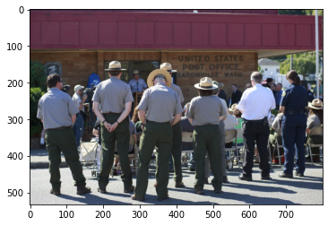

```
Actual Label:
Predicted Label in order: Is this picture of the
 Mount Rainier National Park, Moscow Raceway, or Temple of Heaven?
```

```python
def suggest_locations(img_path):
    # get landmark predictions
    predicted_landmarks = predict_landmarks(img_path, 3)

    ## TODO: display image and display landmark predictions
    img = Image.open(img_path).convert('RGB')
    plt.imshow(img)
    plt.show()

    print(f"Actual Label: {img_path.split('/')[2][3:].replace('_',' ').split('.')[0]}")
    print(f"Predicted Label in order: Is this picture of the\n {predicted_landmarks[0]}, {predicted_landmarks[1]}, or {predicted_landmarks[2]}?")


# test on a sample image
suggest_locations('C:/Users/sam/Desktop/Udacity/Deep_learning/project2/landmark_images/test/01.Mount_Rainier_National_Park/1f1caef2bd6ae72b.jpg')
```

### (IMPLEMENTATION) Test Algorithm

Three possible points for improvement)

1. Thinking about the model requires more data in order to be better quality of algorithms as the classes is quite a lot (50 classes), since I research on just 10 classes but the trainning data is far higher than what the project used to train on model.
2. Tungin the parameter could also help improve a quality of model since training is so long, I think that more epoch and right learning step will make a better algorithms as well.
3. Try to use different models but vgg16 to implement on transfer learning algorithms and compare the result should be worked if we training as many as we find the right model to transfer.

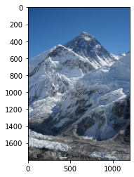

[output not shown]

```python
suggest_locations('C:/Users/sam/Desktop/Udacity/Deep_learning/project2/landmark_images/sample_data/everest.jpg')
```

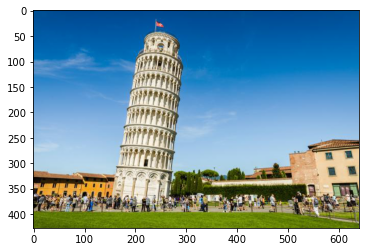

[output not shown]

```python
suggest_locations('C:/Users/sam/Desktop/Udacity/Deep_learning/project2/landmark_images/sample_data/piza.jpg')
```

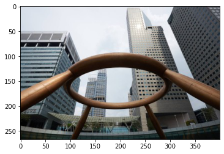

```
Actual Label:
Predicted Label in order: Is this picture of the
 Sydney Harbour Bridge, Niagara Falls, or Sydney Opera House?
```

```python
suggest_locations('C:/Users/sam/Desktop/Udacity/Deep_learning/project2/landmark_images/sample_data/sigapore.jpg')
```

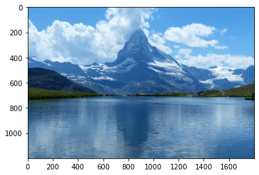

```
Actual Label:
Predicted Label in order: Is this picture of the
 Banff National Park, Matterhorn, or Externsteine?
```

```python
suggest_locations('C:/Users/sam/Desktop/Udacity/Deep_learning/project2/landmark_images/sample_data/matterhorn.jpg')
```